# Midterm 2_ Reem Naji

Author

Reem Naji

Published

November 19, 2025

```
libraries
```

```r
library(tidyverse)
library(gt)
```

```
loading data
```

```r
summerschool <- read_csv("summer_school.csv")
cupid <- read_csv("cupid.csv")
```

## Problem 1

```
Pivoting
```

```r
lettergrade <- pivot_longer(
  summerschool,
  cols = c(term1, term2),
  names_to = "Term",
  values_to = "Grade",
  values_drop_na = TRUE
)
```

```
Data Visualization (Grades)
```

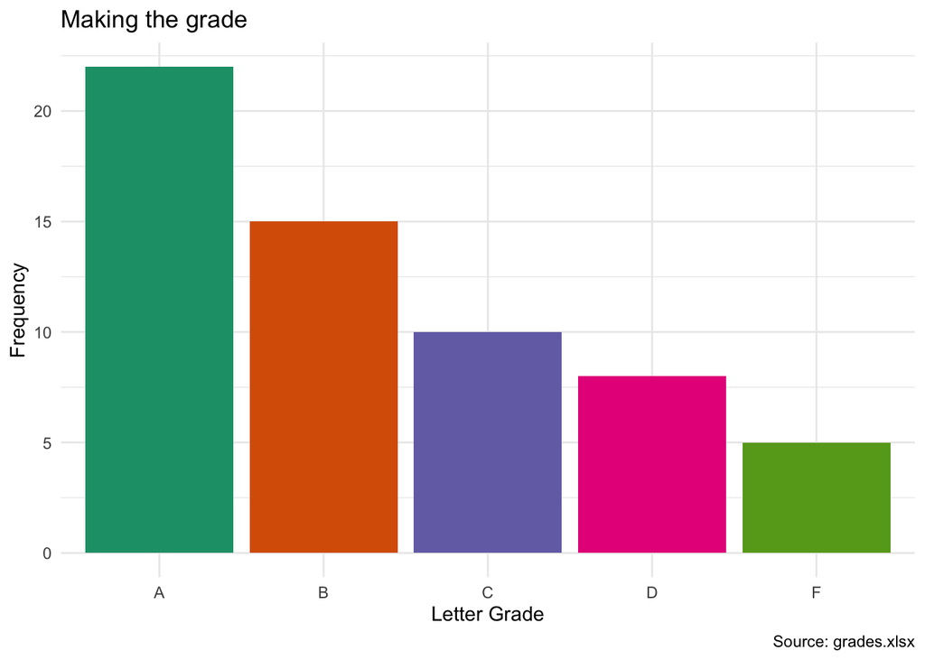

```r
ggplot(lettergrade,
       aes(x = Grade,
           fill = Grade)) +
  geom_bar(show.legend = FALSE) +
  labs(
    title = "Making the grade",
    caption = "Source: grades.xlsx",
    x = "Letter Grade",
    y = "Frequency"
  ) +
  theme_minimal() +
  scale_fill_brewer(palette = "Dark2")
```

## Problem 2

##### Hypothesis Development

- $H_0$: The average GPA for students is 3.1
- $H_a$: The average GPA for students is **not** 3.1

```r
mean(summerschool$gpa,
     na.rm = TRUE)
```

```
[1] 3.025
```

Let’s Visualize:

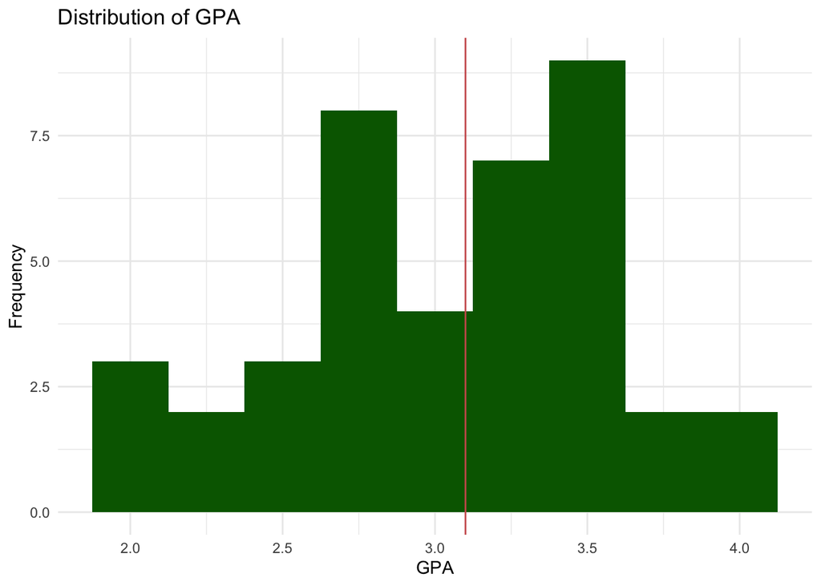

```r
ggplot(
  summerschool,
  aes(x = gpa)) +
geom_histogram(binwidth = 0.25,
               fill= "darkgreen") +
  geom_vline(xintercept = 3.1,
             color = "indianred")+
  labs(title= "Distribution of GPA",
       x= "GPA",
       y= "Frequency") +
  theme_minimal() +
  scale_fill_brewer(palette = "Dark2")
```

```r
t.test(summerschool$gpa,
       mu = 3.1)
```

```
    One Sample t-test

data:  summerschool$gpa
t = -0.91614, df = 39, p-value = 0.3652
alternative hypothesis: true mean is not equal to 3.1
95 percent confidence interval:
 2.859412 3.190588
sample estimates:
mean of x
    3.025
```

```r
MOE <- (3.1 - 3.025) / 2
MOE
```

```
[1] 0.0375
```

## Problem 3

```
Problem 3
```

```r
lettergrade %>% # Since I already created this sub data set for problem 1 using pivot_longer.
  mutate(
    Term_val = ifelse(Term == "term1", 1, 2) # Displaying numerical values for the Term column
  ) %>%
  group_by(Term_val) %>%
  summarise(
    Number = n(),
    DF_rate = mean(Grade %in% c("D", "F")) # Displaying the average of only D & F grades
  ) %>%
  gt() %>%
  cols_label(
    Term_val = "Term",
    DF_rate  = "DF Rate"
  )
```

| Term | Number | DF Rate |
| --- | --- | --- |
| 1 | 40 | 0.10 |
| 2 | 20 | 0.45 |

## Problem 4

```
Filtering NAs
```

```r
cupid_sm <- cupid %>%
  filter(!is.na(body_type), !is.na(drugs))
```

```
Body type & drug use contingency table
```

```r
common_bodytype <- cupid_sm %>%
  count(body_type) %>%
  slice_max(n, n = 5) %>% # keeping only the  five most frequently appearing body types
  pull(body_type)

# 2. Filtering to the five most common body types
cupid_top <- cupid_sm %>%
  filter(body_type %in% common_bodytype)

table <- table(cupid_top$body_type, cupid_top$drugs)

# Displaying table as gt for better aesthetics after converting to data frame
as.data.frame.matrix(table) %>%
  rownames_to_column(var = "Body Type") %>%
  gt() %>%
  tab_header(
    title = "Body type & Drug Use on OKCupid",
    subtitle = "Is body type and drug use related?"
  )
```

Body type & Drug Use on OKCupid

Is body type and drug use related?

| Body Type | never | often | sometimes |
| --- | --- | --- | --- |
| athletic | 197 | 1 | 29 |
| average | 238 | 0 | 43 |
| curvy | 72 | 0 | 19 |
| fit | 194 | 0 | 40 |
| thin | 70 | 1 | 26 |

```
Data Visualization (Body type & drug use)
```

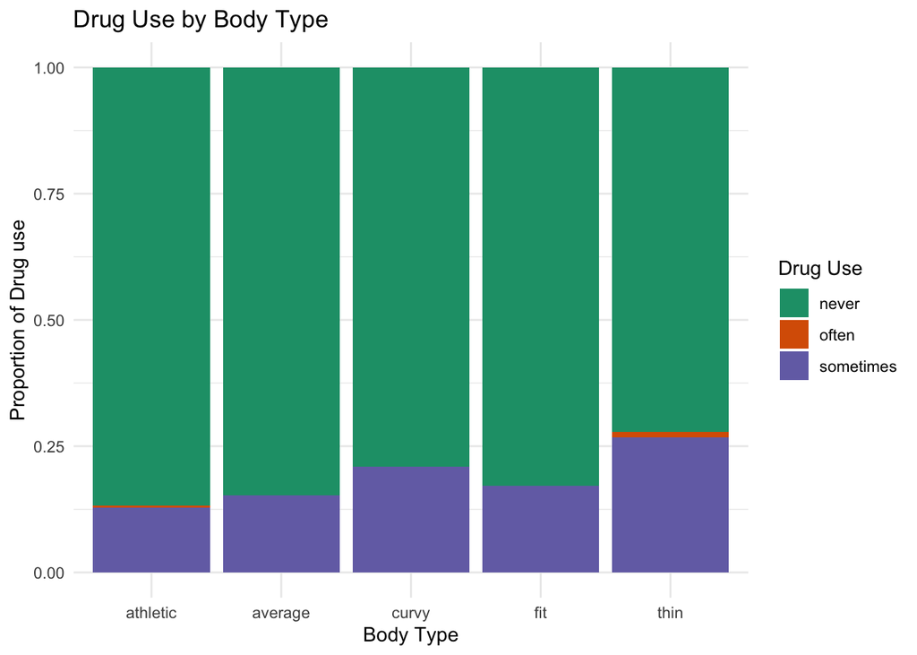

```r
ggplot(
  cupid_top,
  aes
  (x = body_type,
    fill = drugs)) +
  geom_bar(position = "fill") +
  labs(
    title = "Drug Use by Body Type",
    x = "Body Type",
    y = "Proportion of Drug use",
    fill = "Drug Use"
  ) +
  theme_minimal() +
  scale_fill_brewer(palette = "Dark2")
```

The bar chart shows that people with thin and curvy body types report higher use of drugs under the `sometimes` label. However, the overall patterns are consistent among respondents, with very minor differences that I don’t believe it would be accurate to claim a strong relationship based of it. As our data shows no dramatic patterns, and without more details on the types of drugs or what `sometimes` actually means, it would inaccurate to suggest a meaningful association between body type and drug use when there’s barely any.

## Problem 5

**Prompt** According to Gallup, 3.4% of U.S. adults identify as gay and 5.2% identify as bisexual. Assume the remaining 91.4% are straight (which isn’t really true). Is the cupid data set consistent with this information? Follow all best practices from class.

Hypothesis Development: $H_0$ : The proportions of sexual orientations in cupid dataset match those in Gallup survey. $H_a$ : The proportions of sexual orientations in cupid dataset **does not** match those in Gallup survey

```
Count of sexual orientations in the dataset
```

```r
obs <- table(cupid$orientation)
print (obs)
```

```
bisexual      gay straight
      80      138     1255
```

```
Expected versus actual proportions
```

```r
exp_props <- c(bisexual = 0.052, gay = 0.034, straight = 0.914)
cupid_total <- sum(obs)

expected_counts <- exp_props * cupid_total
print(expected_counts)
```

```
bisexual      gay straight
  76.596   50.082 1346.322
```

```
Chi test
```

```r
chisq.test(obs, p = exp_props)
```

```
    Chi-squared test for given probabilities

data:  obs
X-squared = 160.68, df = 2, p-value < 2.2e-16
```

with a p-value of $2.2\times10^{-16}$, we reject the null hypothesis. The data provides a strong evidence that Gallup’s estimates of sexual orientations in the U.S. is not consistent with those in the Cupid data set.

# Problem 6

```
Ethncity Data Wrengling
```

```r
ethnicity_clean <- cupid %>%
  filter(!is.na(ethnicity)) %>%
  separate_rows(ethnicity, sep = ",") %>%
  mutate(
    ethnicity = trimws(ethnicity),
    ethnicity_sm = case_when(
      ethnicity %in% c("white", "White") ~ "White",
      ethnicity %in% c("black", "Black", "african american", "african-american") ~ "Black",
      ethnicity %in% c("asian", "Asian") ~ "Asian",
      ethnicity %in% c("middle eastern", "middle-eastern") ~ "Middle Eastern",
      ethnicity %in% c("hispanic / latin", "hispanic", "latin", "latino") ~ "Hispanic",
      TRUE ~ "Other"
    )
  )
```

```
Six most common
```

```r
six_ethos <- ethnicity_clean %>%
  count(ethnicity_sm, sort = TRUE) %>%
  slice_head(n = 6)
```

```
Data Visualization (Common Ethnicities)
```

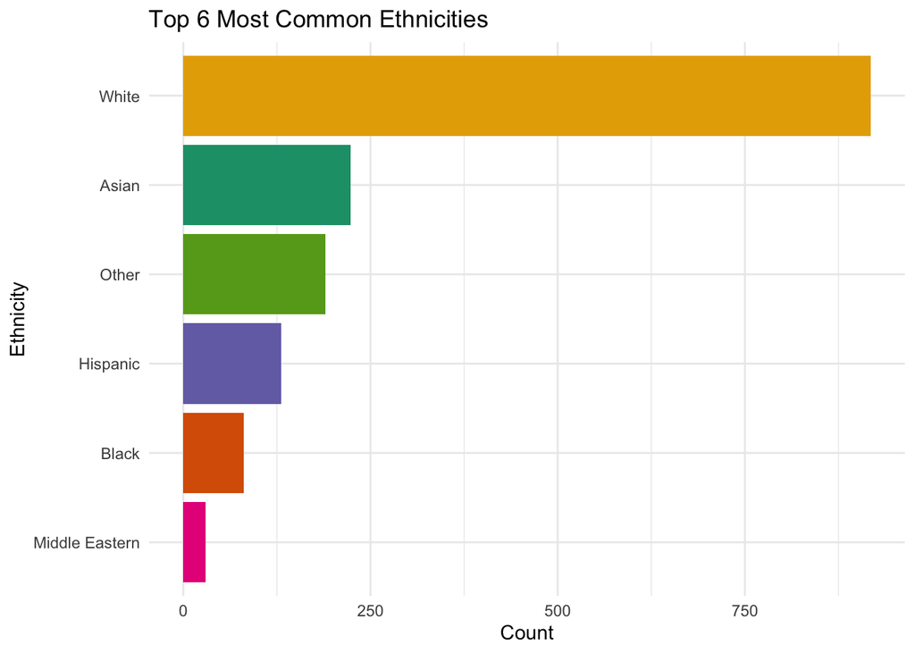

```r
ggplot(
  six_ethos,
  aes(x = reorder(ethnicity_sm, n),
      y = n,
      fill = ethnicity_sm)) +
  geom_col(show.legend = FALSE) +
  coord_flip() +
  labs(
    title = "Top 6 Most Common Ethnicities",
    x = "Ethnicity",
    y = "Count"
  ) +
  theme_minimal() +
  scale_fill_brewer(palette = "Dark2")
```